# Discussion 10 Functional data analysis and tips for final project

Wenzhuo Wu, Chen Qian

June.05.2023

# 1 Functional data analysis

*This material was originally developed by Manuel Oviedo de la Fuente*

## 1.1 Functional Regression Model

Regression models are those techniques for modeling and analyzing the relationship between a dependent variable and one or more independent variables. When one of the variables have a functional nature, we have functional regression models.

This section is devoted to all the functional regression models where the response variable is scalar and at least, there is one functional covariate.

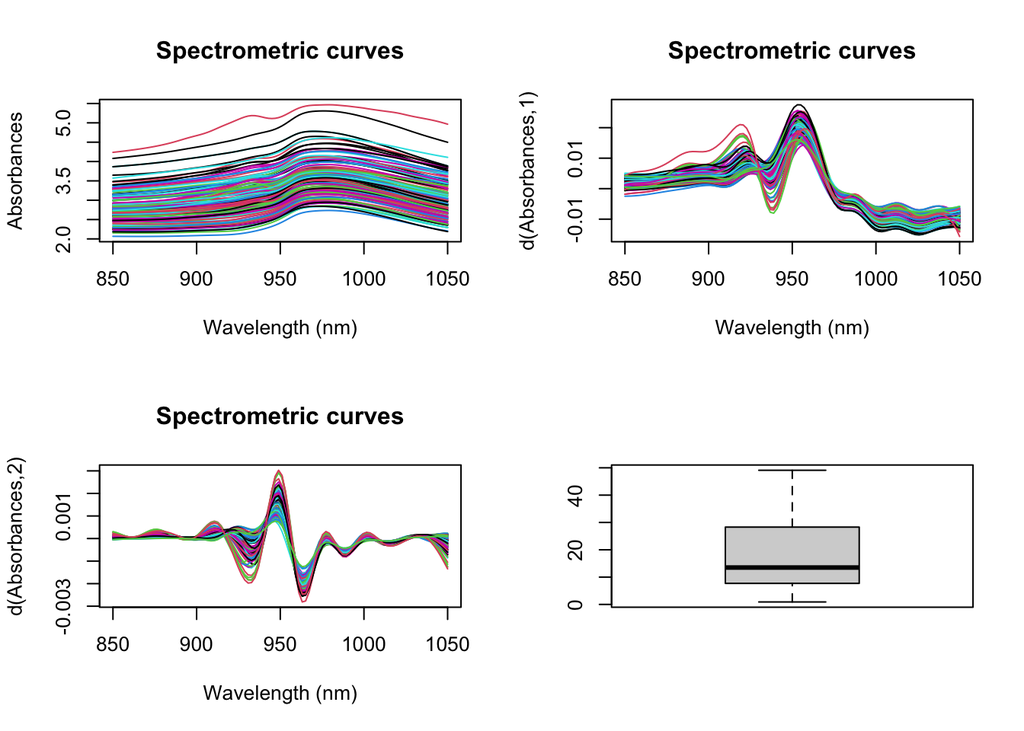

```r
library(fda.usc)
data(tecator)
absorp<-tecator$absorp
ind<-sample(215,129) #ind = 1:129
tt = absorp[["argvals"]]
y = tecator[["y"]]$Fat[ind]
X = absorp[ind, ]
X.d1 = fdata.deriv(X, nbasis = 19, nderiv = 1)
X.d2 = fdata.deriv(X, nbasis = 19, nderiv = 2)
par(mfrow=c(2,2))
plot(X)
plot(X.d1)
plot(X.d2)
boxplot(y)
```

In the following sections, regression methods implemented –fda.usc– pacakge in the package are presented one by one and illustrated with examples for estimating the *Fat* content of the Tecator dataset.

## 1.2 Functional linear model (FLR) with basis representation

fregre.basis() fucntion uses fixed basis: B–spline, Fourier, etc. Ramsay and Silverman (2005), Cardot, Ferraty, and Sarda (1999)) The next code illustrates how to estimate the fat contents using a sample of absorbances curves.

```r
rangett <- X$rangeval
basis1 = create.bspline.basis(rangeval = rangett, nbasis = 17)
basis2 = create.bspline.basis(rangeval = rangett, nbasis = 7)
res.basis0 = fregre.basis(X, y, basis.x = basis1, basis.b = basis2)
res.basis1 = fregre.basis(X.d1, y, basis.x = basis1, basis.b = basis2)
res.basis2 = fregre.basis(X.d2, y, basis.x = basis1, basis.b = basis2)
res.basis0$r2;res.basis1$r2;res.basis2$r2
```

```
## [1] 0.9412898
```

```
## [1] 0.941747
```

```
## [1] 0.9530877
```

```r
summary(res.basis2)
```

```
##  *** Summary Functional Data Regression with representation in Basis ***
##
## Call:
## fregre.basis(fdataobj = X.d2, y = y, basis.x = basis1, basis.b = basis2)
##
## Residuals:
##      Min       1Q   Median       3Q      Max
## -11.8034  -1.6750  -0.1417   1.8136   6.1685
##
## Coefficients:
##                Estimate Std. Error t value Pr(>|t|)
## (Intercept)   1.799e+01  2.476e-01  72.659  < 2e-16 ***
## X.d2.bspl4.1 -1.371e+04  3.503e+03  -3.913 0.000151 ***
## X.d2.bspl4.2  1.006e+04  2.796e+03   3.597 0.000467 ***
## X.d2.bspl4.3 -5.443e+02  1.493e+03  -0.364 0.716136
## X.d2.bspl4.4 -2.439e+02  1.141e+03  -0.214 0.831035
## X.d2.bspl4.5 -3.714e+02  1.110e+03  -0.335 0.738421
## X.d2.bspl4.6  4.023e+03  1.947e+03   2.066 0.040976 *
## X.d2.bspl4.7 -6.634e+03  1.338e+03  -4.960 2.33e-06 ***
## ---
## Signif. codes:  0 '***' 0.001 '**' 0.01 '*' 0.05 '.' 0.1 ' ' 1
##
## Residual standard error: 2.812 on 121 degrees of freedom
## Multiple R-squared:  0.9531, Adjusted R-squared:  0.9504
## F-statistic: 351.2 on 7 and 121 DF,  p-value: < 2.2e-16
##
## -Names of possible atypical curves: 44
## -Names of possible influence curves: 45 44
```

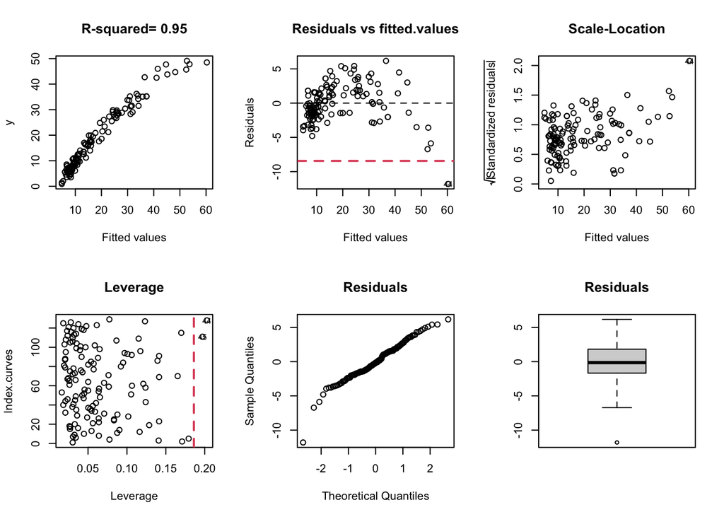

```r
par(mfrow=c(1,3))
plot(res.basis0$beta.est)
```

```
## [1] "done"
```

```r
## [1] "done"
plot(res.basis1$beta.est)
```

```
## [1] "done"
```

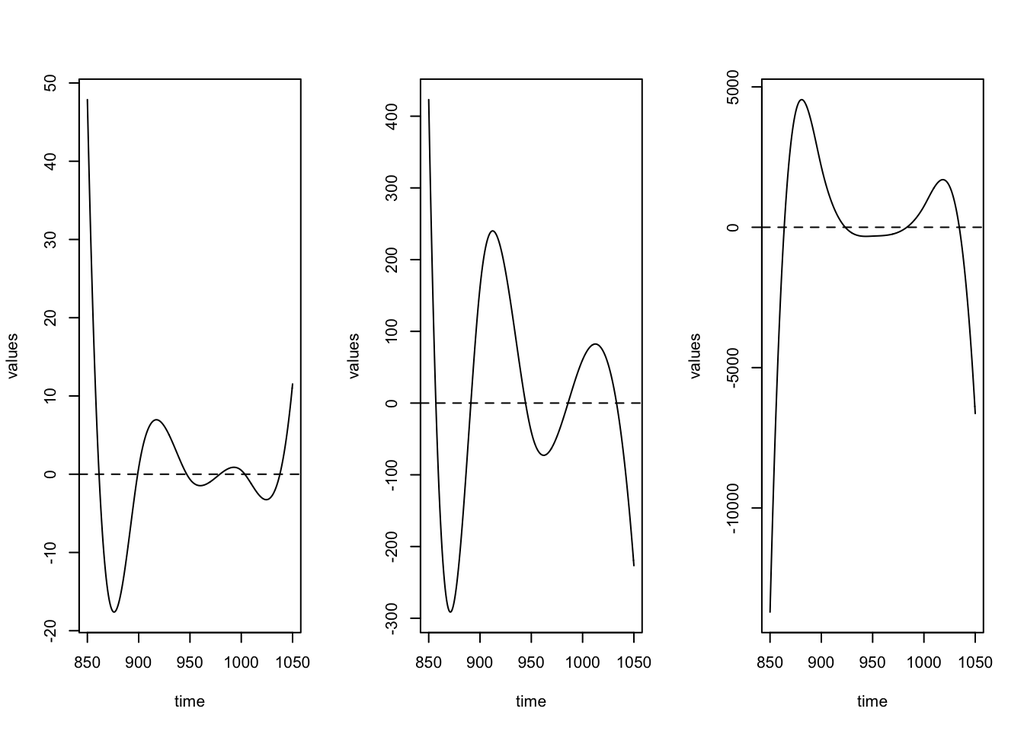

```
## [1] "done"
```

```r
## [1] "done"
plot(res.basis2$beta.est)
```

The choice of the appropiate basis (and the number of basis elements) becomes now in a crucial step:

```r
res.basis.cv = fregre.basis(X, y)
summary(res.basis.cv)
```

```
##  *** Summary Functional Data Regression with representation in Basis ***
##
## Call:
## fregre.basis(fdataobj = X, y = y)
##
## Residuals:
##      Min       1Q   Median       3Q      Max
## -14.0878  -1.5583   0.2243   1.6809   5.3965
##
## Coefficients:
##              Estimate Std. Error t value Pr(>|t|)
## (Intercept)   17.9915     0.2406  74.767  < 2e-16 ***
## X.bspl4.1   -312.5107    71.6979  -4.359 2.81e-05 ***
## X.bspl4.2    399.2223    86.4538   4.618 9.96e-06 ***
## X.bspl4.3   -254.4139    57.4209  -4.431 2.11e-05 ***
## X.bspl4.4     88.9970    28.2562   3.150  0.00207 **
## X.bspl4.5    -27.4921    16.8058  -1.636  0.10453
## X.bspl4.6     10.2395    13.4017   0.764  0.44636
## X.bspl4.7      8.3822    21.4277   0.391  0.69637
## X.bspl4.8    -55.5108    52.8931  -1.049  0.29610
## X.bspl4.9    114.9984    90.9477   1.264  0.20856
## X.bspl4.10  -106.5310    81.0924  -1.314  0.19150
## ---
## Signif. codes:  0 '***' 0.001 '**' 0.01 '*' 0.05 '.' 0.1 ' ' 1
##
## Residual standard error: 2.733 on 118 degrees of freedom
## Multiple R-squared:  0.9568, Adjusted R-squared:  0.9531
## F-statistic: 261.3 on 10 and 118 DF,  p-value: < 2.2e-16
##
## -Names of possible atypical curves: 44
## -Names of possible influence curves: 131 7 86 45
```

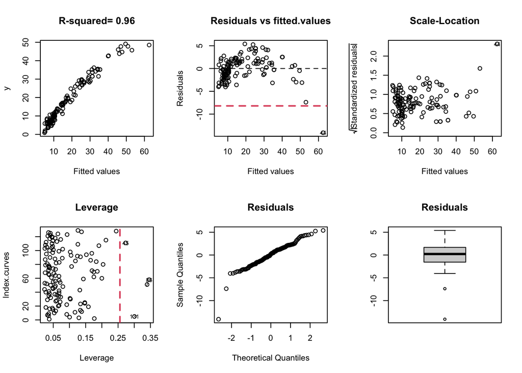

## 1.3 Generalized Linear Models (Müller and Stadtmüller 2005)

```r
data(tecator)
names(tecator)[2]<-"df"
tecator$df$fat15<-ifelse(tecator$df$Fat<15,0,1)
tecator$absorp.d2=fdata.deriv(tecator$absorp.fdata,nderiv=2)
res.glm<-fregre.glm(fat15 ~ absorp.d2,data=tecator,family=binomial())
#summary(a)
yfit<-ifelse(res.glm$fitted.values<.5,0,1)
table(tecator$df$fat15,yfit)
```

```
##    yfit
##       0   1
##   0 109   3
##   1   2 101
```

More detail can be found [https://rpubs.com/moviedo/fda_usc_regression]

# 2 Tips for final project

## 2.1 Abstract

An overview of this project.

## 2.2 Introduction

The introduction states the questions of interest and the impact of results of this data analysis. In addition, the introduction provides a brief overview of the problem setup, source of data, key variables, and possible hypotheses. Readers that are familiar with this topic can easily understand the introduction.

## 2.3 Background

The report contains basic discussion of the source of data, target population, sampling mechanism, explanation of variables, and very brief reviews of existing research or known results that are relevant to this topic. The background discussion gives readers, who are familiar with this topic or statistics, sufficient information to (i) evaluate the plausibility of this report and (ii) learn more about this topic if desired.

## 2.4 Descriptive analysis

The descriptive analysis provides basic univariate descriptive statistics for relevant variables (mean, standard deviations, missing values, quantiles, etc.), and a few multivariate description of key variables. Readers that are familiar with this topic or statistics gain basic insights of this data set, e.g., being able to generate hypotheses, spot abnormality (or the lack of), propose statistical models, evaluate the plausibility of assumptions.

In this part, the main task is to address questions in Part one.

Part 1 (15 points). Exploratory data analysis. In this part, we will explore the features of the data sets in order to build our prediction model. In particular, we would like to (i) describe the data structures across sessions (e.g., number of neurons, number of trials, stimuli conditions, feedback types), (ii) explore the neural activities during each trial, (iii) explore the changes across trials, and (iv) explore homogeneity and heterogeneity across sessions and mice.

**Grading criteria:** **To address (i), it would be best to use a table. Remember to explain what each variable represents.** **For (ii), (iii), and (iv), at least one figure should be included for each. Ensure that the x-axis and y-axis are clearly labeled, and provide an appropriate caption for each figure and table.** **Also, make sure to number them clearly for easy reference.** **Make sure you answered all questions in Part one. I hope you can answer those questions in order, but it’s not requuied.** **Lastly, it’s important to explain why you included those plots and how they address the questions in Part 1. This will help readers understand the significance of the data presented and how it contributes to the overall findings of the project.**

I will give you an example for problem 1.

The data for this project consists of eighteen sessions involving four different mice. The variables utilized in the project include `mouse_name` (the name of the mouse for specific sessions), `date_exp` (the date of the experiment), `n_brain_area` (the unique brain area involved), `n_neurons` (the number of neurons), `n_trials` (the number of trials in each session), and `success_rate` (the ratio of successful trials to the total number of trials). It is important to note that the selected data does not contain any missing values (**Table 1**).

| mouse_name | date_exp | n_brain_area | n_neurons | n_trials | success_rate |
| --- | --- | --- | --- | --- | --- |
| Cori | 2016-12-14 | 8 | 734 | 114 | 0.61 |
| Cori | 2016-12-17 | 5 | 1070 | 251 | 0.63 |
| Cori | 2016-12-18 | 11 | 619 | 228 | 0.66 |
| Forssmann | 2017-11-01 | 11 | 1769 | 249 | 0.67 |
| Forssmann | 2017-11-02 | 10 | 1077 | 254 | 0.66 |
| Forssmann | 2017-11-04 | 5 | 1169 | 290 | 0.74 |
| Forssmann | 2017-11-05 | 8 | 584 | 252 | 0.67 |
| Hench | 2017-06-15 | 15 | 1157 | 250 | 0.64 |
| Hench | 2017-06-16 | 12 | 788 | 372 | 0.69 |
| Hench | 2017-06-17 | 13 | 1172 | 447 | 0.62 |
| Hench | 2017-06-18 | 6 | 857 | 342 | 0.80 |
| Lederberg | 2017-12-05 | 12 | 698 | 340 | 0.74 |
| Lederberg | 2017-12-06 | 15 | 983 | 300 | 0.80 |
| Lederberg | 2017-12-07 | 10 | 756 | 268 | 0.69 |
| Lederberg | 2017-12-08 | 8 | 743 | 404 | 0.76 |
| Lederberg | 2017-12-09 | 6 | 474 | 280 | 0.72 |
| Lederberg | 2017-12-10 | 6 | 565 | 224 | 0.83 |
| Lederberg | 2017-12-11 | 10 | 1090 | 216 | 0.81 |

**Table 1**. Data structure across sessions.

This is show you how to include a figure without showing the code.

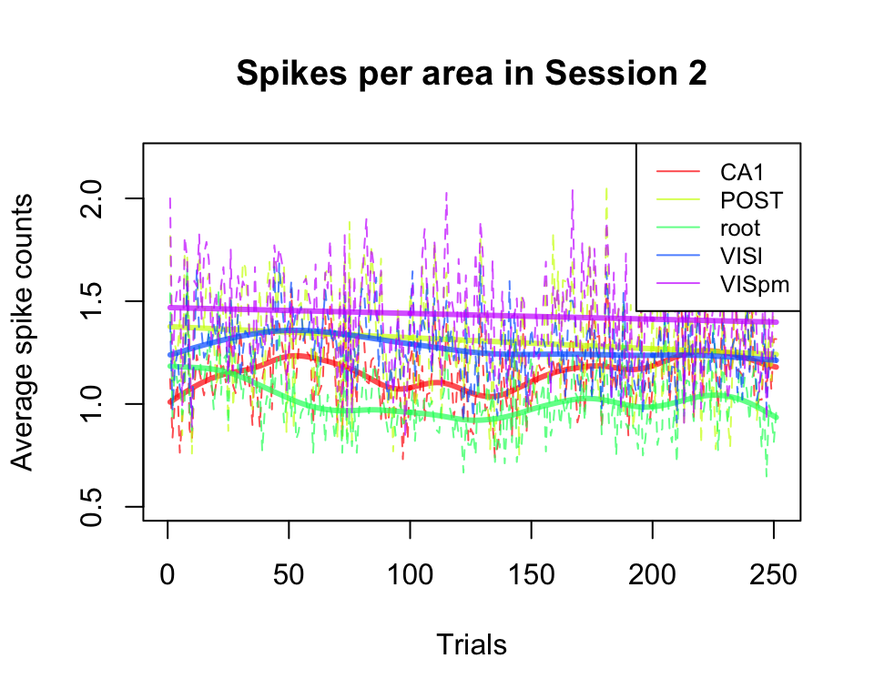

**Figure 1**. Average spike count across trials in session 2.

## 2.5 Data integration

Part 2 (15 points). Data integration. Using the findings in Part 1, we will propose an approach to combine data across trials by (i) extracting the shared patters across sessions and/or (ii) addressing the differences between sessions. The goal of this part is to enable the borrowing of information across sessions to enhance the prediction performance in Part 3.

**For the course project, if students choose not to conduct any sophisticated methods for data integration, they can choose to focus on utilizing the behavioural information. For instance, they can start by recognizing the different rewarding mechanisms (0-0, equal but non-zero, unequal), the time since the start of the experiment, session IDs for the same mouse, etc.**

## 2.6 Predictive modeling

Part 3 (15 points). Model training and prediction. Finally, we will build a prediction model to predict the outcome (i.e., feedback types). The performance will be evaluated on two test sets of 100 trials randomly selected from Session 1 and Session 18, respectively. The test sets will be released on the day of submission when you need to evaluate the performance of your model.

Using method like logistic regression, SVM, etc for prediction.

## 2.7 Prediction performance on the test sets

Using confusion matrix and indicators we discussed in Discussion: Model comparison (5/23/2023).

Review: Confusion Matrix: A confusion matrix provides a tabular summary of classifier predictions compared to actual class labels. It includes true positives, true negatives, false positives, and false negatives. From the confusion matrix, various performance metrics can be derived, such as accuracy, precision, recall, and F1-score.

Precision: Precision measures the proportion of correctly predicted positive instances out of all instances predicted as positive. It quantifies the classifier’s ability to avoid false positives.

Recall: Recall (also known as sensitivity or true positive rate) calculates the proportion of correctly predicted positive instances out of all actual positive instances. It represents the classifier’s ability to identify all positive cases.

F1-score: The F1-score combines precision and recall into a single metric. It provides a balanced measure of a classifier’s performance by considering both false positives and false negatives.

## 2.8 Discussion

## Appendix

```r
knitr::opts_chunk$set(fig.pos = 'H')
library(htmlwidgets)
library(fda.usc)
data(tecator)
absorp<-tecator$absorp
ind<-sample(215,129) #ind = 1:129
tt = absorp[["argvals"]]
y = tecator[["y"]]$Fat[ind]
X = absorp[ind, ]
X.d1 = fdata.deriv(X, nbasis = 19, nderiv = 1)
X.d2 = fdata.deriv(X, nbasis = 19, nderiv = 2)
par(mfrow=c(2,2))
plot(X)
plot(X.d1)
plot(X.d2)
boxplot(y)
rangett <- X$rangeval
basis1 = create.bspline.basis(rangeval = rangett, nbasis = 17)
basis2 = create.bspline.basis(rangeval = rangett, nbasis = 7)
res.basis0 = fregre.basis(X, y, basis.x = basis1, basis.b = basis2)
res.basis1 = fregre.basis(X.d1, y, basis.x = basis1, basis.b = basis2)
res.basis2 = fregre.basis(X.d2, y, basis.x = basis1, basis.b = basis2)
res.basis0$r2;res.basis1$r2;res.basis2$r2
summary(res.basis2)

par(mfrow=c(1,3))
plot(res.basis0$beta.est)
## [1] "done"
plot(res.basis1$beta.est)
## [1] "done"
plot(res.basis2$beta.est)
res.basis.cv = fregre.basis(X, y)
summary(res.basis.cv)
data(tecator)
names(tecator)[2]<-"df"
tecator$df$fat15<-ifelse(tecator$df$Fat<15,0,1)
tecator$absorp.d2=fdata.deriv(tecator$absorp.fdata,nderiv=2)
res.glm<-fregre.glm(fat15 ~ absorp.d2,data=tecator,family=binomial())
#summary(a)
yfit<-ifelse(res.glm$fitted.values<.5,0,1)
table(tecator$df$fat15,yfit)
setwd("/Users/chenqian/Desktop/Data")
session=list()
for(i in 1:18){
  session[[i]]=readRDS(paste('session',i,'.rds',sep=''))
}
# Summarize the information across sessions:
# Knowing what summary we want to report, we can create a tibble:
# All values in this function serve only as place holders
library(tidyverse)
library(magrittr)
library(knitr)
library(dplyr)
n.session=length(session)

# in library tidyverse

meta <- tibble(
  mouse_name = rep('name',n.session),
  date_exp =rep('dt',n.session),
  n_brain_area = rep(0,n.session),
  n_neurons = rep(0,n.session),
  n_trials = rep(0,n.session),
  success_rate = rep(0,n.session)
)


for(i in 1:n.session){
  tmp = session[[i]];
  meta[i,1]=tmp$mouse_name;
  meta[i,2]=tmp$date_exp;
  meta[i,3]=length(unique(tmp$brain_area));
  meta[i,4]=dim(tmp$spks[[1]])[1];
  meta[i,5]=length(tmp$feedback_type);
  meta[i,6]=mean(tmp$feedback_type+1)/2;
}
kable(meta, format = "html", table.attr = "class='table table-striped'",digits=2)
i.s=2 # indicator for this session

i.t=1 # indicator for this trial

spk.trial = session[[i.s]]$spks[[i.t]]
area=session[[i.s]]$brain_area

# We need to first calculate the number of spikes for each neuron during this trial
spk.count=apply(spk.trial,1,sum)

# for(i in 1:dim(spk.trial)[1]){
#  spk.count[i]=sum(spk.trial[i,])
# }

# Next we take the average of spikes across neurons that live in the same area

# You can use tapply() or group_by() in dplyr

# tapply():
spk.average.tapply=tapply(spk.count, area, mean)


# dplyr:
# To use dplyr you need to create a data frame
tmp <- data.frame(
  area = area,
  spikes = spk.count
)
# Calculate the average by group using dplyr
spk.average.dplyr =tmp %>%
  group_by(area) %>%
  summarize(mean= mean(spikes))

# Wrapping up the function:

average_spike_area<-function(i.t,this_session){
  spk.trial = this_session$spks[[i.t]]
  area= this_session$brain_area
  spk.count=apply(spk.trial,1,sum)
  spk.average.tapply=tapply(spk.count, area, mean)
  return(spk.average.tapply)
  }

# Test the function
average_spike_area(1,this_session = session[[i.s]])

n.trial=length(session[[i.s]]$feedback_type)
n.area=length(unique(session[[i.s]]$brain_area ))
# Alternatively, you can extract these information in the meta that we created before.

# We will create a data frame that contain the average spike counts for each area, feedback type,  the two contrasts, and the trial id

trial.summary =matrix(nrow=n.trial,ncol= n.area+1+2+1)
for(i.t in 1:n.trial){
  trial.summary[i.t,]=c(average_spike_area(i.t,this_session = session[[i.s]]),
                          session[[i.s]]$feedback_type[i.t],
                        session[[i.s]]$contrast_left[i.t],
                        session[[i.s]]$contrast_right[i.s],
                        i.t)
}

colnames(trial.summary)=c(names(average_spike_area(i.t,this_session = session[[i.s]])), 'feedback', 'left contr.','right contr.','id' )

# Turning it into a data frame
trial.summary <- as_tibble(trial.summary)
area.col=rainbow(n=n.area,alpha=0.7)
# In base R, I usually initiate a blank plot before drawing anything on it
plot(x=1,y=0, col='white',xlim=c(0,n.trial),ylim=c(0.5,2.2), xlab="Trials",ylab="Average spike counts", main=paste("Spikes per area in Session", i.s))


for(i in 1:n.area){
  lines(y=trial.summary[[i]],x=trial.summary$id,col=area.col[i],lty=2,lwd=1)
  lines(smooth.spline(trial.summary$id, trial.summary[[i]]),col=area.col[i],lwd=3)
  }
legend("topright",
  legend = colnames(trial.summary)[1:n.area],
  col = area.col,
  lty = 1,
  cex = 0.8
)
sessionInfo()
```